# eDNA Cost-Benefit Analysis: Optimizing COTS Control

Author

Analysis Report

Published

July 30, 2026

```r
library(dplyr)
# Robustly find reefDNA regardless of render context
pkg_path <- if (dir.exists("reefDNA")) "reefDNA" else if (dir.exists("../reefDNA")) "../reefDNA" else "."
devtools::load_all(pkg_path)
library(knitr)
library(ggplot2)
library(scales)
library(tidyr)
library(rpart)
library(leaflet)
library(sf)
library(htmltools)
library(stringr)

# Read the processed data
combined_data <- read.csv("combined_reef_analysis_v2.csv")
top_20_annual <- read.csv("top_20_annual_wasted_v2.csv")
full_matched_data <- read.csv("full_matched_data_v2.csv")

# Baseline Financial Metrics
cost_per_on_water_day <- 24000
diver_hours_per_day <- 24
cost_per_diver_hour <- 1000  # Updated: $1,000 per diver hour
program_cost <- 400000  # Updated: $400K eDNA program cost
total_reefs_surveyed <- 120
tactical_reefs <- 20
operational_tactical_reefs <- 55 # Updated to 55 reefs for projection
edna_cost_per_reef <- program_cost / total_reefs_surveyed
```

## Executive Summary

This report evaluates the potential return on investment (ROI) of incorporating eDNA surveys into the Crown-of-Thorns Starfish (COTS) control program to safely identify and “close” tactical reefs. By eliminating “ghost culling”—the effort spent culling reefs that lack significant COTS populations—the program could redirect significant vessel and diver time.

This analysis relies on actual historical cull efficiency data matched with eDNA records since 2020. **All savings estimates include 80% confidence intervals** derived from 10,000 bootstrap resamples of the historical reef-year data (n = 73).

### Baseline Unit Costs

- **Cost per Diver Hour:** $1,000
- **eDNA Program Total Cost:** $400,000
- **Assumed Number of Tactical Reefs (per year):** 55 (Projected operational scale)
- **eDNA Average Cost per Reef:** $3,333.33

## Historical eDNA Efficacy Assessment (2020-Present)

Rather than just looking at the worst performing reefs, we have broadened our search to **all reefs that have both eDNA and active culling data since 2020**.

We evaluate eDNA rigorously as a diagnostic test to see what would have happened if we explicitly closed reefs based on statistical combinations.

### Classification Logic & Defining “Ghost Culls”

To rigorously score False Positives and False Negatives, we must define the ultimate ground truth. * **The Predictor Rule (Prediction):** A statistical cutoff indicating whether we should “Close” our vessel operations or keep the reef “Open” for diving. * **The Ground Truth (Actual Cull Outcome):** * *Current Assumption:* An **Outbreak (Needed)** is formally declared if *any* dive on that reef registered a CPUE $> 0.04$. If a reef met this criteria, diving was validated. * *What is a Ghost Cull?* A **Ghost Cull (False Positive)** is classified when the predictor rule says we should keep the reef open to cull it, but following the initial Manta Tows/scouts, the subsequent Culling Data proves that **zero dives ever exceeded 0.04 CPUE**. In other words, if a reef actually had dives recovering $> 0.04$ CPUE, it is completely exonerated—it is *not* a ghost cull, and our models strictly punish the metric (registering a False Negative Missed Outbreak) if we mistakenly attempted to close it.

#### Temporal Correction: Post-eDNA Filtering

To avoid inflating the estimated savings, **all culling metrics are computed using only dives that occurred on or after the earliest eDNA sample date** for each reef-year. This ensures:

1. **Hours reported as “avoidable” could actually have been avoided** — we only count culling effort that happened after the eDNA result would have been available to inform the closure decision.
2. **Ghost-cull classification is not contaminated by pre-eDNA evidence** — a reef is not falsely exonerated (or falsely condemned) based on CPUE data that preceded the eDNA sample.

For reef-years where all culling occurred before the eDNA sample, those records are excluded entirely from the confusion matrix (there is no post-eDNA culling to evaluate).

### Baseline Confusion Matrix (eDNA Only)

If we applied the `< 45%` rule retrospectively to all fully matched reef/years, these are the outcomes:

```r
matrix_data <- full_matched_data %>%
    mutate(
        Predict_Close = eDNA_Pct_Positive < 45,
        Truth_Needed = (Proportion_NeededLow > 0) | (Proportion_NeededHigh > 0), # Was there an outbreak?
        Confusion_Class = case_when(
            Predict_Close & !Truth_Needed ~ "True Negative (Correctly Closed)",
            Predict_Close & Truth_Needed ~ "False Negative (Missed Outbreak)",
            !Predict_Close & Truth_Needed ~ "True Positive (Correctly Kept Open)",
            !Predict_Close & !Truth_Needed ~ "False Positive (Ghost Culled)"
        )
    )

conf_summary <- matrix_data %>%
    group_by(Confusion_Class) %>%
    summarise(
        `Reef Occurrences` = n(),
        `Diver Hrs Rep` = round(sum(Total_Diver_Hours), 1),
        `0-0.02 Hrs (%)` = paste0(round((sum(Wasted_Diver_Hours) / max(sum(Total_Diver_Hours), 1)) * 100, 1), "%"),
        `0.02-0.04 Hrs (%)` = paste0(round((sum(Borderline_Diver_Hours) / max(sum(Total_Diver_Hours), 1)) * 100, 1), "%"),
        `0.04-0.08 Hrs (%)` = paste0(round((sum(NeededLow_Diver_Hours) / max(sum(Total_Diver_Hours), 1)) * 100, 1), "%"),
        `>0.08 Hrs (%)` = paste0(round((sum(NeededHigh_Diver_Hours) / max(sum(Total_Diver_Hours), 1)) * 100, 1), "%")
    ) %>%
    arrange(desc(`Reef Occurrences`))

kable(conf_summary, caption = "Baseline eDNA Confusion Matrix (with Diver Hour bins)")
```

Baseline eDNA Confusion Matrix (with Diver Hour bins)

| Confusion_Class | Reef Occurrences | Diver Hrs Rep | 0-0.02 Hrs (%) | 0.02-0.04 Hrs (%) | 0.04-0.08 Hrs (%) | >0.08 Hrs (%) |
| --- | --- | --- | --- | --- | --- | --- |
| True Positive (Correctly Kept Open) | 39 | 8371.5 | 27.7% | 19.4% | 25% | 27.9% |
| True Negative (Correctly Closed) | 18 | 859.8 | 93.9% | 6.1% | 0% | 0% |
| False Positive (Ghost Culled) | 12 | 512.8 | 89.2% | 10.8% | 0% | 0% |
| False Negative (Missed Outbreak) | 4 | 583.2 | 52.1% | 21.7% | 20.4% | 5.8% |

## Multivariate Diagnostic Engine

To aggressively eliminate False Negatives (missed outbreaks) and False Positives (wasted culling trips), we can synthesize additional site data. By bringing in **Manta Tow Scars** and applying an **Initial Scout Cull** (recording CPUE strictly from the first day on-site before committing heavily to the reef), we enhance prediction accuracy.

### Baseline Comparison: Manta Scars Only

To fully understand the value eDNA adds, we must evaluate what happens if we operate solely on traditional Manta Tow scarring data. **Close Reef IF Manta Scars < 10%**:

```r
matrix_data_scars <- matrix_data %>%
    mutate(
        Pct_Tows_With_Scars = replace_na(Pct_Tows_With_Scars, 0),
        Predict_Close_Scars = (Pct_Tows_With_Scars < 10),
        Confusion_Class_Scars = case_when(
            Predict_Close_Scars & !Truth_Needed ~ "True Negative (Correctly Closed)",
            Predict_Close_Scars & Truth_Needed ~ "False Negative (Missed Outbreak)",
            !Predict_Close_Scars & Truth_Needed ~ "True Positive (Correctly Kept Open)",
            !Predict_Close_Scars & !Truth_Needed ~ "False Positive (Ghost Culled)"
        )
    )

conf_summary_scars <- matrix_data_scars %>%
    group_by(Confusion_Class_Scars) %>%
    summarise(
        `Reef Occurrences` = n(),
        `Diver Hrs Rep` = round(sum(Total_Diver_Hours), 1),
        `0-0.02 Hrs (%)` = paste0(round((sum(Wasted_Diver_Hours) / max(sum(Total_Diver_Hours), 1)) * 100, 1), "%"),
        `0.02-0.04 Hrs (%)` = paste0(round((sum(Borderline_Diver_Hours) / max(sum(Total_Diver_Hours), 1)) * 100, 1), "%"),
        `0.04-0.08 Hrs (%)` = paste0(round((sum(NeededLow_Diver_Hours) / max(sum(Total_Diver_Hours), 1)) * 100, 1), "%"),
        `>0.08 Hrs (%)` = paste0(round((sum(NeededHigh_Diver_Hours) / max(sum(Total_Diver_Hours), 1)) * 100, 1), "%")
    ) %>%
    arrange(desc(`Reef Occurrences`))

kable(conf_summary_scars, caption = "Univariate Baseline: Scars < 10% (No eDNA factors)")
```

Univariate Baseline: Scars < 10% (No eDNA factors)

| Confusion_Class_Scars | Reef Occurrences | Diver Hrs Rep | 0-0.02 Hrs (%) | 0.02-0.04 Hrs (%) | 0.04-0.08 Hrs (%) | >0.08 Hrs (%) |
| --- | --- | --- | --- | --- | --- | --- |
| True Positive (Correctly Kept Open) | 30 | 8126.2 | 26.6% | 19.9% | 25.7% | 27.9% |
| True Negative (Correctly Closed) | 22 | 935.6 | 92.3% | 7.7% | 0% | 0% |
| False Negative (Missed Outbreak) | 13 | 828.4 | 56.1% | 16.1% | 15.3% | 12.5% |
| False Positive (Ghost Culled) | 8 | 437.0 | 92% | 8% | 0% | 0% |

### Hardcoded Rule: eDNA combined with Manta Scars

If we refine the rule to mathematically state: **Close Reef IF (eDNA < 45%) AND (Manta Scars < 10%)**:

```r
matrix_data_r1 <- matrix_data %>%
    mutate(
        Pct_Tows_With_Scars = replace_na(Pct_Tows_With_Scars, 0),
        Predict_Close = (eDNA_Pct_Positive < 45) & (Pct_Tows_With_Scars < 10),
        Confusion_Class_R1 = case_when(
            Predict_Close & !Truth_Needed ~ "True Negative (Correctly Closed)",
            Predict_Close & Truth_Needed ~ "False Negative (Missed Outbreak)",
            !Predict_Close & Truth_Needed ~ "True Positive (Correctly Kept Open)",
            !Predict_Close & !Truth_Needed ~ "False Positive (Ghost Culled)"
        )
    )

conf_summary_r1 <- matrix_data_r1 %>%
    group_by(Confusion_Class_R1) %>%
    summarise(
        `Reef Occurrences` = n(),
        `Diver Hrs Rep` = round(sum(Total_Diver_Hours), 1),
        `0-0.02 Hrs (%)` = paste0(round((sum(Wasted_Diver_Hours) / max(sum(Total_Diver_Hours), 1)) * 100, 1), "%"),
        `0.02-0.04 Hrs (%)` = paste0(round((sum(Borderline_Diver_Hours) / max(sum(Total_Diver_Hours), 1)) * 100, 1), "%"),
        `0.04-0.08 Hrs (%)` = paste0(round((sum(NeededLow_Diver_Hours) / max(sum(Total_Diver_Hours), 1)) * 100, 1), "%"),
        `>0.08 Hrs (%)` = paste0(round((sum(NeededHigh_Diver_Hours) / max(sum(Total_Diver_Hours), 1)) * 100, 1), "%")
    ) %>%
    arrange(desc(`Reef Occurrences`))

kable(conf_summary_r1, caption = "Multivariate Rule 1 (eDNA + Scars)")
```

Multivariate Rule 1 (eDNA + Scars)

| Confusion_Class_R1 | Reef Occurrences | Diver Hrs Rep | 0-0.02 Hrs (%) | 0.02-0.04 Hrs (%) | 0.04-0.08 Hrs (%) | >0.08 Hrs (%) |
| --- | --- | --- | --- | --- | --- | --- |
| True Positive (Correctly Kept Open) | 40 | 8796.2 | 29% | 19.4% | 24.9% | 26.6% |
| False Positive (Ghost Culled) | 16 | 647.9 | 86.3% | 13.7% | 0% | 0% |
| True Negative (Correctly Closed) | 14 | 724.7 | 97.4% | 2.6% | 0% | 0% |
| False Negative (Missed Outbreak) | 3 | 158.4 | 43.8% | 24.2% | 15.7% | 16.3% |

### Baseline Comparison 2: Field Data Only (Scars + Scout Cull)

Before utilizing expensive eDNA processing, what happens if we strictly merge our free, existing field data? **Close Reef IF (Manta Scars < 15%) AND (Initial Scout CPUE < 0.02)**. *(Note: Because this rule inherently requires the Initial Scout Cull, we deduct Scout Diver Hours from the True Negative yield).*

```r
matrix_data_field <- matrix_data %>%
    mutate(
        Pct_Tows_With_Scars = replace_na(Pct_Tows_With_Scars, 0),
        Initial_CPUE = replace_na(Initial_CPUE, 0),
        Predict_Close = (Pct_Tows_With_Scars < 15) & (Initial_CPUE < 0.02),
        Confusion_Class_Field = case_when(
            Predict_Close & !Truth_Needed ~ "True Negative (Correctly Closed)",
            Predict_Close & Truth_Needed ~ "False Negative (Missed Outbreak)",
            !Predict_Close & Truth_Needed ~ "True Positive (Correctly Kept Open)",
            !Predict_Close & !Truth_Needed ~ "False Positive (Ghost Culled)"
        ),
        Net_Saved_Hrs = ifelse(Confusion_Class_Field == "True Negative (Correctly Closed)", Total_Diver_Hours - Scout_Diver_Hours, Total_Diver_Hours)
    )

conf_summary_field <- matrix_data_field %>%
    group_by(Confusion_Class_Field) %>%
    summarise(
        `Reef Occurrences` = n(),
        `Net Diver Hrs Rep` = round(sum(Net_Saved_Hrs, na.rm = TRUE), 1),
        `0-0.02 Hrs (%)` = paste0(round((sum(Wasted_Diver_Hours) / max(sum(Total_Diver_Hours), 1)) * 100, 1), "%"),
        `0.02-0.04 Hrs (%)` = paste0(round((sum(Borderline_Diver_Hours) / max(sum(Total_Diver_Hours), 1)) * 100, 1), "%"),
        `0.04-0.08 Hrs (%)` = paste0(round((sum(NeededLow_Diver_Hours) / max(sum(Total_Diver_Hours), 1)) * 100, 1), "%"),
        `>0.08 Hrs (%)` = paste0(round((sum(NeededHigh_Diver_Hours) / max(sum(Total_Diver_Hours), 1)) * 100, 1), "%")
    ) %>%
    arrange(desc(`Reef Occurrences`))

kable(conf_summary_field, caption = "Baseline 2: Field Rules strictly (Scars < 15% + Scout Culling < 0.02)")
```

Baseline 2: Field Rules strictly (Scars < 15% + Scout Culling < 0.02)

| Confusion_Class_Field | Reef Occurrences | Net Diver Hrs Rep | 0-0.02 Hrs (%) | 0.02-0.04 Hrs (%) | 0.04-0.08 Hrs (%) | >0.08 Hrs (%) |
| --- | --- | --- | --- | --- | --- | --- |
| True Positive (Correctly Kept Open) | 35 | 8384.0 | 26.9% | 20% | 25.7% | 27.5% |
| True Negative (Correctly Closed) | 23 | 763.0 | 97.3% | 2.7% | 0% | 0% |
| False Negative (Missed Outbreak) | 8 | 570.6 | 64.5% | 12.5% | 11.4% | 11.6% |
| False Positive (Ghost Culled) | 7 | 240.3 | 68.2% | 31.8% | 0% | 0% |

### Hardcoded Rule 2: eDNA, Manta Scars, and Initial Scout CPUE

If we deploy a highly integrated diagnostic expanding the relaxed envelopes but demanding an in-water check: **Close Reef IF (eDNA < 50%) AND (Manta Scars < 15%) AND (Initial Scout CPUE < 0.02)**: *(Note: Because this rule requires the Initial Scout Cull, we mathematically deduct the Scout Diver Hours from the functionally Saved Hours yield).*

```r
matrix_data_r2 <- matrix_data %>%
    mutate(
        Pct_Tows_With_Scars = replace_na(Pct_Tows_With_Scars, 0),
        Initial_CPUE = replace_na(Initial_CPUE, 0),
        Predict_Close = (eDNA_Pct_Positive < 50) & (Pct_Tows_With_Scars < 15) & (Initial_CPUE < 0.02),
        Confusion_Class_R2 = case_when(
            Predict_Close & !Truth_Needed ~ "True Negative (Correctly Closed)",
            Predict_Close & Truth_Needed ~ "False Negative (Missed Outbreak)",
            !Predict_Close & Truth_Needed ~ "True Positive (Correctly Kept Open)",
            !Predict_Close & !Truth_Needed ~ "False Positive (Ghost Culled)"
        ),
        Net_Saved_Hrs = ifelse(Confusion_Class_R2 == "True Negative (Correctly Closed)", Total_Diver_Hours - Scout_Diver_Hours, Total_Diver_Hours)
    )

conf_summary_r2 <- matrix_data_r2 %>%
    group_by(Confusion_Class_R2) %>%
    summarise(
        `Reef Occurrences` = n(),
        `Net Diver Hrs Rep` = round(sum(Net_Saved_Hrs, na.rm = TRUE), 1),
        `0-0.02 Hrs (%)` = paste0(round((sum(Wasted_Diver_Hours) / max(sum(Total_Diver_Hours), 1)) * 100, 1), "%"),
        `0.02-0.04 Hrs (%)` = paste0(round((sum(Borderline_Diver_Hours) / max(sum(Total_Diver_Hours), 1)) * 100, 1), "%"),
        `0.04-0.08 Hrs (%)` = paste0(round((sum(NeededLow_Diver_Hours) / max(sum(Total_Diver_Hours), 1)) * 100, 1), "%"),
        `>0.08 Hrs (%)` = paste0(round((sum(NeededHigh_Diver_Hours) / max(sum(Total_Diver_Hours), 1)) * 100, 1), "%")
    ) %>%
    arrange(desc(`Reef Occurrences`))

kable(conf_summary_r2, caption = "Multivariate Rule 2 (eDNA + Scars + Scout Culling)")
```

Multivariate Rule 2 (eDNA + Scars + Scout Culling)

| Confusion_Class_R2 | Reef Occurrences | Net Diver Hrs Rep | 0-0.02 Hrs (%) | 0.02-0.04 Hrs (%) | 0.04-0.08 Hrs (%) | >0.08 Hrs (%) |
| --- | --- | --- | --- | --- | --- | --- |
| True Positive (Correctly Kept Open) | 41 | 8816.3 | 28.5% | 19.6% | 25.1% | 26.7% |
| True Negative (Correctly Closed) | 18 | 490.3 | 96.8% | 3.2% | 0% | 0% |
| False Positive (Ghost Culled) | 12 | 599.1 | 86.3% | 13.7% | 0% | 0% |
| False Negative (Missed Outbreak) | 2 | 138.4 | 79.2% | 10.3% | 1.1% | 9.4% |

### Algorithmic Optimization (Decision Trees via rpart)

A decision tree (`rpart`) mathematically scans historical records across eDNA, Manta Tow, and Initial CPUE variables to determine absolute optimal thresholds for closure decisions. *(Note: Because these models inherently require divers doing an initial scout cull to get `Initial_CPUE`, the ultimate “Saved Hours” in these models formally subtracts those day-1 Scout Diver Hours from the savings yield).*

Instead of blindly eliminating all False Positives or False Negatives completely, we present three models based on standard statistical weighting metrics:

```r
ml_data <- matrix_data %>%
    mutate(
        Pct_Tows_With_Scars = replace_na(Pct_Tows_With_Scars, 0),
        Initial_CPUE = replace_na(Initial_CPUE, 0),
        Truth_Needed_Factor = factor(ifelse(Truth_Needed, "Outbreak", "Ghost"))
    )
```

#### Model 1: Balanced Accuracy

**Focus:** Treats Ghost Culling and Missed Outbreaks equally (1:1 ratio). Optimizes purely for the highest raw predictive accuracy (Gini index). This represents an operational baseline.

```r
tree_bal <- rpart(Truth_Needed_Factor ~ eDNA_Pct_Positive + Pct_Tows_With_Scars + Initial_CPUE,
    data = ml_data, method = "class"
)

# Determine if Initial_CPUE was used to conditionally subtract scout hours
used_scout_bal <- "Initial_CPUE" %in% tree_bal$frame$var

ml_data$Pred_Bal <- predict(tree_bal, type = "class")
ml_data <- ml_data %>%
    mutate(
        Class_Bal = case_when(
            Pred_Bal == "Ghost" & Truth_Needed_Factor == "Ghost" ~ "True Negative (Correctly Closed)",
            Pred_Bal == "Ghost" & Truth_Needed_Factor == "Outbreak" ~ "False Negative (Missed Outbreak)",
            Pred_Bal == "Outbreak" & Truth_Needed_Factor == "Outbreak" ~ "True Positive (Correctly Kept Open)",
            Pred_Bal == "Outbreak" & Truth_Needed_Factor == "Ghost" ~ "False Positive (Ghost Culled)"
        ),
        Net_Saved_Bal = ifelse(Class_Bal == "True Negative (Correctly Closed)" & used_scout_bal, Total_Diver_Hours - Scout_Diver_Hours, Total_Diver_Hours)
    )

kable(ml_data %>%
    group_by(Class_Bal) %>%
    summarise(
        `Reef Occurrences` = n(),
        `Net Diver Hrs` = round(sum(Net_Saved_Bal, na.rm = TRUE), 1),
        `0-0.02 Hrs (%)` = paste0(round((sum(Wasted_Diver_Hours) / max(sum(Total_Diver_Hours), 1)) * 100, 1), "%"),
        `0.02-0.04 Hrs (%)` = paste0(round((sum(Borderline_Diver_Hours) / max(sum(Total_Diver_Hours), 1)) * 100, 1), "%"),
        `0.04-0.08 Hrs (%)` = paste0(round((sum(NeededLow_Diver_Hours) / max(sum(Total_Diver_Hours), 1)) * 100, 1), "%"),
        `>0.08 Hrs (%)` = paste0(round((sum(NeededHigh_Diver_Hours) / max(sum(Total_Diver_Hours), 1)) * 100, 1), "%")
    ), caption = "Model 1: Balanced Accuracy Outcomes")
```

Model 1: Balanced Accuracy Outcomes

| Class_Bal | Reef Occurrences | Net Diver Hrs | 0-0.02 Hrs (%) | 0.02-0.04 Hrs (%) | 0.04-0.08 Hrs (%) | >0.08 Hrs (%) |
| --- | --- | --- | --- | --- | --- | --- |
| False Positive (Ghost Culled) | 10 | 562.2 | 83.7% | 16.3% | 0% | 0% |
| True Negative (Correctly Closed) | 20 | 522.6 | 98.1% | 1.9% | 0% | 0% |
| True Positive (Correctly Kept Open) | 43 | 8954.7 | 29.3% | 19.5% | 24.7% | 26.4% |

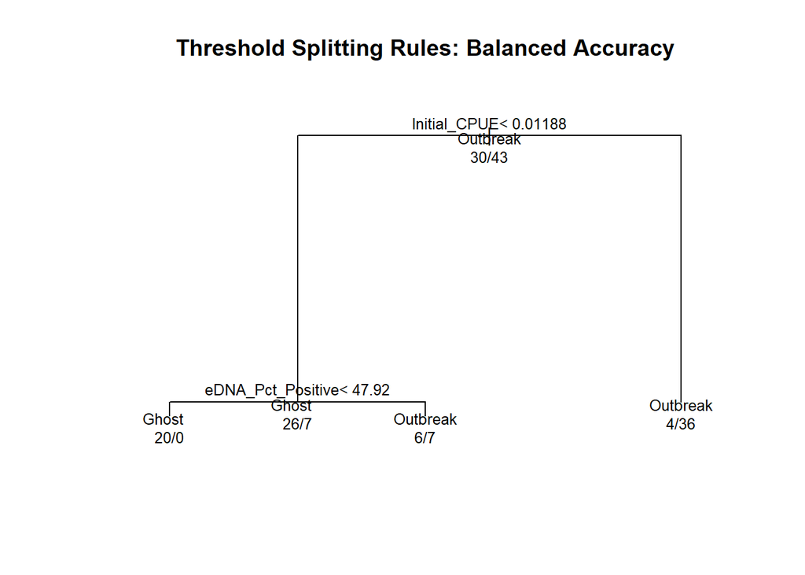

```r
plot(tree_bal, margin = 0.1, main = "Threshold Splitting Rules: Balanced Accuracy")
text(tree_bal, use.n = TRUE, all = TRUE, cex = 0.8)
```

#### Model 2: F1-Score Proxy (Harmonic Mean)

```r
loss_f1 <- matrix(c(0, 2.5, 1, 0), byrow = TRUE, nrow = 2)
tree_f1 <- rpart(Truth_Needed_Factor ~ eDNA_Pct_Positive + Pct_Tows_With_Scars + Initial_CPUE,
    data = ml_data, parms = list(loss = loss_f1)
)

used_scout_f1 <- "Initial_CPUE" %in% tree_f1$frame$var

ml_data$Pred_F1 <- predict(tree_f1, type = "class")
ml_data <- ml_data %>%
    mutate(
        Class_F1 = case_when(
            Pred_F1 == "Ghost" & Truth_Needed_Factor == "Ghost" ~ "True Negative (Correctly Closed)",
            Pred_F1 == "Ghost" & Truth_Needed_Factor == "Outbreak" ~ "False Negative (Missed Outbreak)",
            Pred_F1 == "Outbreak" & Truth_Needed_Factor == "Outbreak" ~ "True Positive (Correctly Kept Open)",
            Pred_F1 == "Outbreak" & Truth_Needed_Factor == "Ghost" ~ "False Positive (Ghost Culled)"
        ),
        Net_Saved_F1 = ifelse(Class_F1 == "True Negative (Correctly Closed)" & used_scout_f1, Total_Diver_Hours - Scout_Diver_Hours, Total_Diver_Hours)
    )

kable(ml_data %>%
    group_by(Class_F1) %>%
    summarise(
        `Reef Occurrences` = n(),
        `Net Diver Hrs` = round(sum(Net_Saved_F1, na.rm = TRUE), 1),
        `0-0.02 Hrs (%)` = paste0(round((sum(Wasted_Diver_Hours) / max(sum(Total_Diver_Hours), 1)) * 100, 1), "%"),
        `0.02-0.04 Hrs (%)` = paste0(round((sum(Borderline_Diver_Hours) / max(sum(Total_Diver_Hours), 1)) * 100, 1), "%"),
        `0.04-0.08 Hrs (%)` = paste0(round((sum(NeededLow_Diver_Hours) / max(sum(Total_Diver_Hours), 1)) * 100, 1), "%"),
        `>0.08 Hrs (%)` = paste0(round((sum(NeededHigh_Diver_Hours) / max(sum(Total_Diver_Hours), 1)) * 100, 1), "%")
    ), caption = "Model 2: F1-Score Harmonic Mean Outcomes")
```

Model 2: F1-Score Harmonic Mean Outcomes

| Class_F1 | Reef Occurrences | Net Diver Hrs | 0-0.02 Hrs (%) | 0.02-0.04 Hrs (%) | 0.04-0.08 Hrs (%) | >0.08 Hrs (%) |
| --- | --- | --- | --- | --- | --- | --- |
| False Negative (Missed Outbreak) | 7 | 1597.0 | 42.2% | 17.4% | 19.4% | 20.9% |
| False Positive (Ghost Culled) | 4 | 151.9 | 43.4% | 56.6% | 0% | 0% |
| True Negative (Correctly Closed) | 26 | 821.5 | 98.2% | 1.8% | 0% | 0% |
| True Positive (Correctly Kept Open) | 36 | 7357.6 | 26.5% | 19.9% | 25.9% | 27.6% |

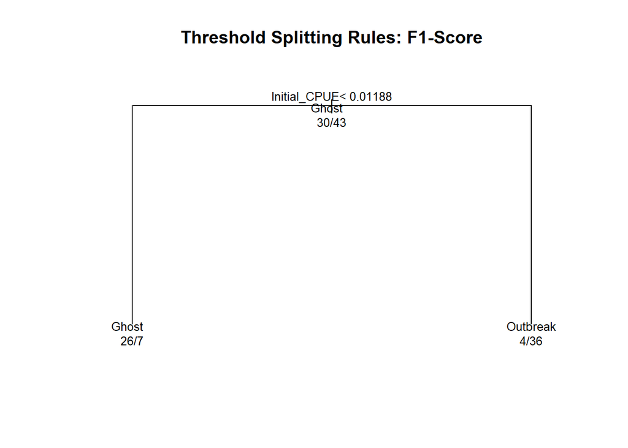

```r
plot(tree_f1, margin = 0.1, main = "Threshold Splitting Rules: F1-Score")
text(tree_f1, use.n = TRUE, all = TRUE, cex = 0.8)
```

#### Model 3: F2-Score Proxy (Eco-Conservative)

```r
loss_f2 <- matrix(c(0, 5, 1, 0), byrow = TRUE, nrow = 2)
tree_f2 <- rpart(Truth_Needed_Factor ~ eDNA_Pct_Positive + Pct_Tows_With_Scars + Initial_CPUE,
    data = ml_data, parms = list(loss = loss_f2)
)

used_scout_f2 <- "Initial_CPUE" %in% tree_f2$frame$var

ml_data$Pred_F2 <- predict(tree_f2, type = "class")
ml_data <- ml_data %>%
    mutate(
        Class_F2 = case_when(
            Pred_F2 == "Ghost" & Truth_Needed_Factor == "Ghost" ~ "True Negative (Correctly Closed)",
            Pred_F2 == "Ghost" & Truth_Needed_Factor == "Outbreak" ~ "False Negative (Missed Outbreak)",
            Pred_F2 == "Outbreak" & Truth_Needed_Factor == "Outbreak" ~ "True Positive (Correctly Kept Open)",
            Pred_F2 == "Outbreak" & Truth_Needed_Factor == "Ghost" ~ "False Positive (Ghost Culled)"
        ),
        Net_Saved_F2 = ifelse(Class_F2 == "True Negative (Correctly Closed)" & used_scout_f2, Total_Diver_Hours - Scout_Diver_Hours, Total_Diver_Hours)
    )

kable(ml_data %>%
    group_by(Class_F2) %>%
    summarise(
        `Reef Occurrences` = n(),
        `Net Diver Hrs` = round(sum(Net_Saved_F2, na.rm = TRUE), 1),
        `0-0.02 Hrs (%)` = paste0(round((sum(Wasted_Diver_Hours) / max(sum(Total_Diver_Hours), 1)) * 100, 1), "%"),
        `0.02-0.04 Hrs (%)` = paste0(round((sum(Borderline_Diver_Hours) / max(sum(Total_Diver_Hours), 1)) * 100, 1), "%"),
        `0.04-0.08 Hrs (%)` = paste0(round((sum(NeededLow_Diver_Hours) / max(sum(Total_Diver_Hours), 1)) * 100, 1), "%"),
        `>0.08 Hrs (%)` = paste0(round((sum(NeededHigh_Diver_Hours) / max(sum(Total_Diver_Hours), 1)) * 100, 1), "%")
    ), caption = "Model 3: F2-Score Eco-Conservative Outcomes")
```

Model 3: F2-Score Eco-Conservative Outcomes

| Class_F2 | Reef Occurrences | Net Diver Hrs | 0-0.02 Hrs (%) | 0.02-0.04 Hrs (%) | 0.04-0.08 Hrs (%) | >0.08 Hrs (%) |
| --- | --- | --- | --- | --- | --- | --- |
| False Negative (Missed Outbreak) | 10 | 1090.8 | 56.8% | 17.5% | 12.3% | 13.4% |
| True Negative (Correctly Closed) | 30 | 904.5 | 92.2% | 7.8% | 0% | 0% |
| True Positive (Correctly Kept Open) | 33 | 7863.9 | 25.5% | 19.8% | 26.5% | 28.3% |

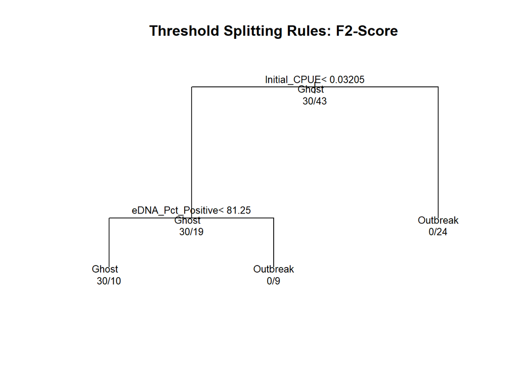

```r
plot(tree_f2, margin = 0.1, main = "Threshold Splitting Rules: F2-Score")
text(tree_f2, use.n = TRUE, all = TRUE, cex = 0.8)
```

### Potential Scale vs Operational Program

The confusion matrices above are based on our historical validation dataset — a relatively small pool of reef-years where we have **both** eDNA samples and post-eDNA culling data. To estimate the annual value of deploying these rules at operational scale, we extrapolate from the historical per-reef averages to a hypothetical program size.

#### Step 1: Key Assumptions

```r
# Show the assumptions table
assumptions_df <- tibble::tibble(
    Parameter = c(
        "Cost per on-water day",
        "Diver hours per on-water day",
        "Implied cost per diver hour",
        "eDNA program total annual cost",
        "Total reefs surveyed with eDNA",
        "eDNA cost per reef (program_cost / reefs_surveyed)",
        "Base tactical reefs (actively targeted for closure)",
        "Monitoring reefs repurposed for tactical use",
        "Total operational tactical reefs per year"
    ),
    Value = c(
        dollar(cost_per_on_water_day),
        paste0(diver_hours_per_day, " hrs"),
        dollar(cost_per_diver_hour),
        dollar(program_cost),
        as.character(total_reefs_surveyed),
        dollar(edna_cost_per_reef),
        as.character(tactical_reefs),
        "20",
        as.character(operational_tactical_reefs)
    )
)
kable(assumptions_df, caption = "Scaling Assumptions")
```

Scaling Assumptions

[output not shown]

#### Step 2: Historical Per-Reef Averages (from validation data)

We compute the **average hours saved** and **average missed outbreaks** per reef-year across the entire historical validation dataset, then scale those averages to the operational program size.

```r
yearly_reef_counts <- matrix_data %>%
    group_by(Year) %>%
    summarise(
        `Reefs Tested` = n()
    )

kable(yearly_reef_counts, caption = "Number of Unique Historical Target Validations per Year")
```

Number of Unique Historical Target Validations per Year

| Year | Reefs Tested |
| --- | --- |
| 2020 | 6 |
| 2021 | 13 |
| 2022 | 12 |
| 2023 | 17 |
| 2024 | 4 |
| 2025 | 21 |

```r
Total_Reefs_Ever_Tested <- nrow(matrix_data_r2)

# ── Approach A: Field Data Only ──────────────────────────────────
TN_count_field <- sum(matrix_data_field$Confusion_Class_Field == "True Negative (Correctly Closed)")
TN_hrs_field <- sum(matrix_data_field$Net_Saved_Hrs[matrix_data_field$Confusion_Class_Field == "True Negative (Correctly Closed)"], na.rm = TRUE)
FN_count_field <- sum(matrix_data_field$Confusion_Class_Field == "False Negative (Missed Outbreak)")

Avg_Saved_Field <- TN_hrs_field / Total_Reefs_Ever_Tested
Avg_FN_Field <- FN_count_field / Total_Reefs_Ever_Tested

# ── Approach B: Integrated eDNA (Rule 2) ─────────────────────────
TN_count_r2 <- sum(matrix_data_r2$Confusion_Class_R2 == "True Negative (Correctly Closed)")
TN_hrs_r2 <- sum(matrix_data_r2$Net_Saved_Hrs[matrix_data_r2$Confusion_Class_R2 == "True Negative (Correctly Closed)"], na.rm = TRUE)
FN_count_r2 <- sum(matrix_data_r2$Confusion_Class_R2 == "False Negative (Missed Outbreak)")

Avg_Saved_R2 <- TN_hrs_r2 / Total_Reefs_Ever_Tested
Avg_FN_R2 <- FN_count_r2 / Total_Reefs_Ever_Tested

# Build the worked-example table
breakdown_df <- tibble::tibble(
    Metric = c(
        "Total reef-years in validation dataset",
        "True Negatives (reefs correctly closed)",
        "Total post-eDNA diver hours saved (TN reefs, net of scout hrs)",
        "False Negatives (missed outbreaks)",
        "Avg hours saved per reef-year (TN_hrs / total_reefs)",
        "Avg missed outbreaks per reef-year (FN_count / total_reefs)"
    ),
    `Approach A: Field Only` = c(
        as.character(Total_Reefs_Ever_Tested),
        as.character(TN_count_field),
        paste0(round(TN_hrs_field, 1), " hrs"),
        as.character(FN_count_field),
        paste0(round(Avg_Saved_Field, 2), " hrs/reef"),
        round(Avg_FN_Field, 3)
    ),
    `Approach B: Integrated eDNA` = c(
        as.character(Total_Reefs_Ever_Tested),
        as.character(TN_count_r2),
        paste0(round(TN_hrs_r2, 1), " hrs"),
        as.character(FN_count_r2),
        paste0(round(Avg_Saved_R2, 2), " hrs/reef"),
        round(Avg_FN_R2, 3)
    )
)
kable(breakdown_df, caption = "Step 2: Historical Per-Reef Averages")
```

Step 2: Historical Per-Reef Averages

| Metric | Approach A: Field Only | Approach B: Integrated eDNA |
| --- | --- | --- |
| Total reef-years in validation dataset | 73 | 73 |
| True Negatives (reefs correctly closed) | 23 | 18 |
| Total post-eDNA diver hours saved (TN reefs, net of scout hrs) | 763 hrs | 490.3 hrs |
| False Negatives (missed outbreaks) | 8 | 2 |
| Avg hours saved per reef-year (TN_hrs / total_reefs) | 10.45 hrs/reef | 6.72 hrs/reef |
| Avg missed outbreaks per reef-year (FN_count / total_reefs) | 0.11 | 0.027 |

#### Step 3: Scale to Operational Program

We multiply the per-reef averages by the operational program size (55 reefs/year) and convert hours to dollars.

```r
# ── Scale to operational program ─────────────────────────────────
Operation_Saved_Field <- Avg_Saved_Field * operational_tactical_reefs
Operation_FN_Field <- Avg_FN_Field * operational_tactical_reefs
financial_savings_field <- Operation_Saved_Field * cost_per_diver_hour

Operation_Saved_R2 <- Avg_Saved_R2 * operational_tactical_reefs
Operation_FN_R2 <- Avg_FN_R2 * operational_tactical_reefs
financial_savings_r2 <- Operation_Saved_R2 * cost_per_diver_hour

# eDNA program costs
cost_edna_testing <- operational_tactical_reefs * edna_cost_per_reef
net_savings_r2 <- financial_savings_r2 - cost_edna_testing

scaling_df <- tibble::tibble(
    Metric = c(
        paste0("Avg hrs saved/reef × ", operational_tactical_reefs, " reefs"),
        paste0("Projected annual hours saved"),
        paste0("× $", format(cost_per_diver_hour, big.mark = ","), "/hr = Gross dollar savings"),
        paste0("Avg FN/reef × ", operational_tactical_reefs, " reefs"),
        "Projected missed outbreaks per year",
        "eDNA testing cost (Approach B only)",
        "NET savings after eDNA costs (Approach B only)"
    ),
    `Approach A: Field Only` = c(
        paste0(round(Avg_Saved_Field, 2), " × ", operational_tactical_reefs),
        paste0(format(round(Operation_Saved_Field, 1), big.mark = ","), " hrs"),
        dollar(financial_savings_field),
        paste0(round(Avg_FN_Field, 3), " × ", operational_tactical_reefs),
        as.character(round(Operation_FN_Field, 1)),
        "$0 (no eDNA needed)",
        dollar(financial_savings_field)
    ),
    `Approach B: Integrated eDNA` = c(
        paste0(round(Avg_Saved_R2, 2), " × ", operational_tactical_reefs),
        paste0(format(round(Operation_Saved_R2, 1), big.mark = ","), " hrs"),
        dollar(financial_savings_r2),
        paste0(round(Avg_FN_R2, 3), " × ", operational_tactical_reefs),
        as.character(round(Operation_FN_R2, 1)),
        dollar(cost_edna_testing),
        dollar(net_savings_r2)
    )
)
kable(scaling_df, caption = "Step 3: Scaled to Operational Program")
```

Step 3: Scaled to Operational Program

| Metric | Approach A: Field Only | Approach B: Integrated eDNA |
| --- | --- | --- |
| Avg hrs saved/reef × 55 reefs | 10.45 × 55 | 6.72 × 55 |
| Projected annual hours saved | 574.8 hrs | 369.4 hrs |
| × $1,000/hr = Gross dollar savings | $574,838 | $369,404 |
| Avg FN/reef × 55 reefs | 0.11 × 55 | 0.027 × 55 |
| Projected missed outbreaks per year | 6 | 1.5 |
| eDNA testing cost (Approach B only) | $0 (no eDNA needed) | $183,333 |
| NET savings after eDNA costs (Approach B only) | $574,838 | $186,071 |

#### Summary

**Approach A: Field Data Only** (Scars < 15% + Scout CPUE < 0.02)

- **Operating Cost:** $0 extra equipment.
- **Projected Annual Hours Saved:** 574.8 diver hours.
- **Gross Dollar Savings:** $574,838.
- **Operational Risk:** Expected to miss **6** genuine outbreaks per year.

**Approach B: Integrated eDNA** (eDNA < 50% + Scars < 15% + Scout CPUE < 0.02)

- **Operating Cost:** $183,333 for eDNA testing across 55 reefs.
- **Projected Annual Hours Saved:** 369.4 diver hours.
- **Gross Dollar Savings:** $369,404.
- **NET Savings (after eDNA costs):** $186,071.
- **Operational Risk:** Expected to miss **1.5** genuine outbreaks per year.

## Uncertainty Quantification: Bootstrap Confidence Intervals

The point estimates above are derived from 73 reef-year observations. To quantify the uncertainty around these savings estimates, we use a **non-parametric case-resampling bootstrap** (10,000 replicates). Each replicate resamples reef-years with replacement, re-applies the classification rule, and recalculates per-reef savings. We report **80% confidence intervals** — the range within which the true savings is expected to fall 80% of the time — as this provides a practical “likely range” for operational budgeting.

### Classification Functions

```r
# Define classification functions for each approach
classify_field_only <- function(df) {
  df %>%
    mutate(
      Pct_Tows_With_Scars = replace_na(Pct_Tows_With_Scars, 0),
      Initial_CPUE = replace_na(Initial_CPUE, 0),
      predict_close = (Pct_Tows_With_Scars < 15) & (Initial_CPUE < 0.02),
      truth_needed = (Proportion_NeededLow > 0) | (Proportion_NeededHigh > 0),
      is_true_negative = predict_close & !truth_needed,
      is_false_negative = predict_close & truth_needed,
      net_saved_hrs = ifelse(is_true_negative, Total_Diver_Hours - Scout_Diver_Hours, 0)
    )
}

classify_edna_integrated <- function(df) {
  df %>%
    mutate(
      Pct_Tows_With_Scars = replace_na(Pct_Tows_With_Scars, 0),
      Initial_CPUE = replace_na(Initial_CPUE, 0),
      predict_close = (eDNA_Pct_Positive < 50) & (Pct_Tows_With_Scars < 15) & (Initial_CPUE < 0.02),
      truth_needed = (Proportion_NeededLow > 0) | (Proportion_NeededHigh > 0),
      is_true_negative = predict_close & !truth_needed,
      is_false_negative = predict_close & truth_needed,
      net_saved_hrs = ifelse(is_true_negative, Total_Diver_Hours - Scout_Diver_Hours, 0)
    )
}

# No-scout approaches (Manta only, eDNA + Manta)
classify_manta_only <- function(df) {
  df %>%
    mutate(
      Pct_Tows_With_Scars = replace_na(Pct_Tows_With_Scars, 0),
      predict_close = (Pct_Tows_With_Scars < 10),
      truth_needed = (Proportion_NeededLow > 0) | (Proportion_NeededHigh > 0),
      is_true_negative = predict_close & !truth_needed,
      is_false_negative = predict_close & truth_needed,
      net_saved_hrs = ifelse(is_true_negative, Total_Diver_Hours, 0)
    )
}

classify_edna_manta <- function(df) {
  df %>%
    mutate(
      Pct_Tows_With_Scars = replace_na(Pct_Tows_With_Scars, 0),
      predict_close = (eDNA_Pct_Positive < 45) & (Pct_Tows_With_Scars < 10),
      truth_needed = (Proportion_NeededLow > 0) | (Proportion_NeededHigh > 0),
      is_true_negative = predict_close & !truth_needed,
      is_false_negative = predict_close & truth_needed,
      net_saved_hrs = ifelse(is_true_negative, Total_Diver_Hours, 0)
    )
}
```

### Bootstrap Results: With Scout Culling (Approaches A vs B)

```r
boot_field <- bootstrap_savings(
  data = full_matched_data,
  classify_fn = classify_field_only,
  n_boot = 10000, ci_level = 0.80,
  cost_per_diver_hour = cost_per_diver_hour,
  edna_cost_per_reef = 0,  # No eDNA cost for field-only
  n_operational_reefs = operational_tactical_reefs
)

boot_edna <- bootstrap_savings(
  data = full_matched_data,
  classify_fn = classify_edna_integrated,
  n_boot = 10000, ci_level = 0.80,
  cost_per_diver_hour = cost_per_diver_hour,
  edna_cost_per_reef = edna_cost_per_reef,
  n_operational_reefs = operational_tactical_reefs
)
```

#### Bootstrap Distributions

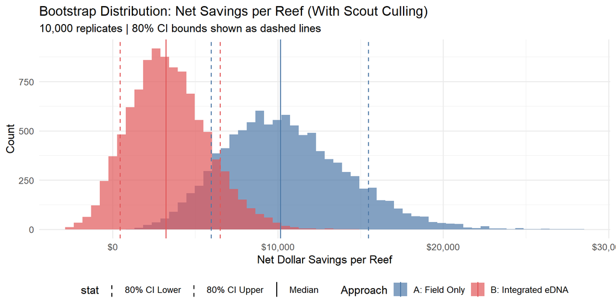

```r
plot_data_ab <- bind_rows(
  boot_field$boot_dist %>% mutate(approach = "A: Field Only"),
  boot_edna$boot_dist %>% mutate(approach = "B: Integrated eDNA")
)

ggplot(plot_data_ab, aes(x = net_dollars_per_reef, fill = approach)) +
  geom_histogram(bins = 60, alpha = 0.7, position = "identity") +
  geom_vline(data = plot_data_ab %>%
    group_by(approach) %>%
    summarise(
      med = median(net_dollars_per_reef),
      lo = quantile(net_dollars_per_reef, 0.10),
      hi = quantile(net_dollars_per_reef, 0.90),
      .groups = "drop"
    ) %>%
    tidyr::pivot_longer(cols = c(med, lo, hi), names_to = "stat", values_to = "val"),
    aes(xintercept = val, colour = approach, linetype = stat),
    linewidth = 0.7
  ) +
  scale_linetype_manual(values = c(med = "solid", lo = "dashed", hi = "dashed"),
                        labels = c("80% CI Lower", "80% CI Upper", "Median")) +
  scale_fill_manual(values = c("A: Field Only" = "#4e79a7", "B: Integrated eDNA" = "#e15759")) +
  scale_colour_manual(values = c("A: Field Only" = "#4e79a7", "B: Integrated eDNA" = "#e15759")) +
  scale_x_continuous(labels = dollar) +
  labs(
    title = "Bootstrap Distribution: Net Savings per Reef (With Scout Culling)",
    subtitle = "10,000 replicates | 80% CI bounds shown as dashed lines",
    x = "Net Dollar Savings per Reef",
    y = "Count",
    fill = "Approach", colour = "Approach"
  ) +
  theme_minimal(base_size = 13) +
  theme(legend.position = "bottom")
```

#### Confidence Interval Summary Table

```r
format_ci_row <- function(boot_res, label, metric_name) {
  row <- boot_res$per_reef %>% filter(metric == metric_name)
  if (nrow(row) == 0) return(NULL)
  tibble::tibble(
    Approach = label,
    Metric = metric_name,
    Median = row$median,
    `80% CI Lower` = row$ci_lower,
    `80% CI Upper` = row$ci_upper
  )
}

ci_table <- bind_rows(
  format_ci_row(boot_field, "A: Field Only", "Hours saved per reef"),
  format_ci_row(boot_edna, "B: Integrated eDNA", "Hours saved per reef"),
  format_ci_row(boot_field, "A: Field Only", "Gross dollar savings per reef"),
  format_ci_row(boot_edna, "B: Integrated eDNA", "Gross dollar savings per reef"),
  format_ci_row(boot_edna, "B: Integrated eDNA", "Net dollar savings per reef (after eDNA cost)"),
  format_ci_row(boot_field, "A: Field Only", "Missed outbreaks per reef"),
  format_ci_row(boot_edna, "B: Integrated eDNA", "Missed outbreaks per reef")
)

# Format dollar columns nicely
ci_table_fmt <- ci_table %>%
  mutate(
    across(c(Median, `80% CI Lower`, `80% CI Upper`), ~ case_when(
      grepl("dollar|Dollar", Metric) ~ dollar(.x),
      grepl("Hours|hours", Metric) ~ paste0(round(.x, 1), " hrs"),
      TRUE ~ as.character(round(.x, 2))
    )),
    `80% CI` = paste0("[", `80% CI Lower`, ", ", `80% CI Upper`, "]")
  ) %>%
  select(Approach, Metric, Median, `80% CI`)

kable(ci_table_fmt, caption = "Per-Reef Savings Estimates with 80% Confidence Intervals (With Scout Culling)")
```

Per-Reef Savings Estimates with 80% Confidence Intervals (With Scout Culling)

| Approach | Metric | Median | 80% CI |
| --- | --- | --- | --- |
| A: Field Only | Hours saved per reef | 10.2 hrs | [6 hrs, 15.5 hrs] |
| B: Integrated eDNA | Hours saved per reef | 6.6 hrs | [3.8 hrs, 9.8 hrs] |
| A: Field Only | Gross dollar savings per reef | $10,150.46 | [$5,957.97, $15,479.11] |
| B: Integrated eDNA | Gross dollar savings per reef | $6,558.90 | [$3,784.13, $9,842.28] |
| B: Integrated eDNA | Net dollar savings per reef (after eDNA cost) | $3,225.57 | [$450.80, $6,508.95] |
| A: Field Only | Missed outbreaks per reef | 0.11 | [0.07, 0.16] |
| B: Integrated eDNA | Missed outbreaks per reef | 0.03 | [0, 0.05] |

#### Scaled Program Estimates with CIs

```r
scaled_table <- bind_rows(
  boot_field$scaled %>% mutate(Approach = "A: Field Only"),
  boot_edna$scaled %>% mutate(Approach = "B: Integrated eDNA")
) %>%
  mutate(
    across(c(median, ci_lower, ci_upper), ~ case_when(
      grepl("dollar|Dollar|savings|Savings", metric) ~ dollar(.x),
      grepl("hours|Hours", metric) ~ paste0(format(round(.x, 0), big.mark = ","), " hrs"),
      TRUE ~ as.character(round(.x, 1))
    )),
    `80% CI` = paste0("[", ci_lower, ", ", ci_upper, "]")
  ) %>%
  select(Approach, Metric = metric, Median = median, `80% CI`)

kable(scaled_table, caption = paste0("Program-Level Estimates Scaled to ", operational_tactical_reefs, " Reefs/Year (80% CI)"))
```

Program-Level Estimates Scaled to 55 Reefs/Year (80% CI)

| Approach | Metric | Median | 80% CI |
| --- | --- | --- | --- |
| A: Field Only | Annual hours saved | 558 hrs | [ 328 hrs, 851 hrs] |
| A: Field Only | Annual gross dollar savings | $558,275 | [$327,688, $851,351] |
| A: Field Only | Annual net savings (after eDNA costs) | $558,275 | [$327,688, $851,351] |
| A: Field Only | Missed outbreaks per year | 6 | [3.8, 9] |
| B: Integrated eDNA | Annual hours saved | 361 hrs | [ 208 hrs, 541 hrs] |
| B: Integrated eDNA | Annual gross dollar savings | $360,740 | [$208,127, $541,326] |
| B: Integrated eDNA | Annual net savings (after eDNA costs) | $177,406 | [$24,794, $357,992] |
| B: Integrated eDNA | Missed outbreaks per year | 1.5 | [0, 3] |